# MLB 2025 Batting Lineup Analysis

Math 534 Project

2026-11-02

# 1 Overview

**Key finding:** under the scope’s exact rules, no 2025 lineup is Traditional and only one game is OPS-ranked, so the planned two-group t-test cannot be run.

- Unit: one team’s half-inning in 2025; each starter is described by 2024 OBP, SLG, and OPS.
- Sample: innings 1-9, complete half-innings before the first substitution, all nine starters with at least 100 PA in 2024.
- Data: the supplied play-by-play workbook plus the MLB Stats API. The supplied player-statistics and probability workbooks are not used.
- To reproduce, Knit in RStudio or run `rmarkdown::render("MLB_Lineup_Analysis.Rmd")`.

```r
library(dplyr)
library(tidyr)
knitr::opts_chunk$set(message = FALSE)
for (d in c("source_cache/mlb_games", "source_cache/mlb_seasons", "processed", "quality")) {
  dir.create(d, recursive = TRUE, showWarnings = FALSE)
}
```

# 2 Data

## 2.1 Play-by-Play Workbook

```r
# Column types are set by hand; otherwise the empty state columns are read as logical.
types <- c("text", "numeric", "date", "text", "numeric", "text", "numeric", "text", "text", "text",
           "numeric", "numeric", "text", "numeric", "text", "text", "numeric")
pbp <- readxl::read_excel("MLB_2023_2026_5Teams_PlayByPlay.xlsx", col_types = types) %>%
  filter(season == 2025) %>%
  mutate(game_id = sub("\\.0+$", "", game_id), batter_id = sub("\\.0+$", "", batter_id))
c(plays = nrow(pbp), games = n_distinct(pbp$game_id))
```

```
## plays games
## 30175   744
```

## 2.2 MLB Stats API

For each 2025 game: starting lineups, substitutions, play results, and the line score. Each file is downloaded once and then read from `source_cache/`.

```r
# Download a JSON file once; later runs read the saved copy.
get_json <- function(url, file) {
  if (!file.exists(file)) saveRDS(list(url = url, data = jsonlite::fromJSON(url, simplifyVector = FALSE)), file)
  readRDS(file)$data
}
val <- function(x) if (is.null(x)) NA else x  # missing JSON field becomes NA

team_ids <- c(Dodgers = 119, Cubs = 112, Cardinals = 138, Angels = 108, Giants = 137)
feed_fields <- paste(c("gamePk", "gameData", "datetime", "officialDate", "status", "abstractGameState",
  "teams", "id", "name", "liveData", "boxscore", "players", "person", "fullName", "battingOrder",
  "stats", "batting", "linescore", "innings", "num", "home", "away", "runs", "plays", "allPlays",
  "atBatIndex", "about", "inning", "halfInning", "isComplete", "matchup", "batter", "result", "event",
  "eventType", "awayScore", "homeScore", "count", "outs", "playEvents", "isSubstitution", "details",
  "player", "position", "code", "runners", "movement", "start", "end", "isOut", "runner"), collapse = ",")

read_game <- function(g) {
  url <- paste0("https://statsapi.mlb.com/api/v1.1/game/", g, "/feed/live?fields=", feed_fields)
  z <- get_json(url, paste0("source_cache/mlb_games/", g, ".rds"))
  team_of <- c(away = names(team_ids)[match(z$gameData$teams$away$id, team_ids)],
               home = names(team_ids)[match(z$gameData$teams$home$id, team_ids)])
  games <- roster <- scores <- plays <- subs <- list()

  # Game date, batting orders, and line score for each of our five teams in this game.
  for (side in c("away", "home")) {
    team <- team_of[[side]]
    if (is.na(team)) next
    half <- if (side == "away") "top" else "bottom"
    games[[side]] <- list(team = team, game_id = g, date = z$gameData$datetime$officialDate,
                          state = z$gameData$status$abstractGameState)
    for (p in z$liveData$boxscore$teams[[side]]$players) {
      if (is.null(p$battingOrder)) next
      order <- as.numeric(p$battingOrder)  # 300 = starter in slot 3, 301 = first substitute in slot 3
      roster[[length(roster) + 1]] <- list(team = team, game_id = g, batter_id = as.character(p$person$id),
                                           player = p$person$fullName, slot = order %/% 100, entry = order %% 100)
    }
    for (i in z$liveData$linescore$innings) {
      if (is.null(i[[side]]$runs)) next  # half-inning not played
      scores[[length(scores) + 1]] <- list(team = team, game_id = g, inning = i$num, inning_half = half,
                                           line_score_runs = i[[side]]$runs)
    }
  }
  roster <- bind_rows(roster)

  # Play results and substitutions.
  for (p in z$liveData$plays$allPlays) {
    half <- p$about$halfInning
    side <- if (half == "top") "away" else "home"
    if (!is.na(team_of[[side]])) {
      batter <- p$matchup$batter$id
      runner_out_only <- length(p$runners) > 0 && all(sapply(p$runners, function(r)
        !is.null(r$movement$start) && isTRUE(r$movement$isOut) && r$details$runner$id != batter))
      plays[[length(plays) + 1]] <- list(team = team_of[[side]], game_id = g, play_index = p$atBatIndex,
        inning = p$about$inning, inning_half = half, batter_id = as.character(batter),
        event = val(p$result$eventType), outs_after = val(p$count$outs),
        score_after = val(p$result[[paste0(side, "Score")]]), runner_out_only = runner_out_only)
    }
    for (e in p$playEvents) {
      if (!isTRUE(e$isSubstitution)) next
      for (j in which(roster$batter_id == as.character(val(e$player$id)) & roster$entry > 0)) {
        subs[[length(subs) + 1]] <- list(team = roster$team[j], game_id = g, batter_id = roster$batter_id[j],
                                         play_index = p$atBatIndex)
      }
    }
  }
  list(games = bind_rows(games), roster = roster, scores = bind_rows(scores),
       plays = bind_rows(plays), subs = bind_rows(subs))
}

read_season <- function(year) {
  url <- paste0("https://statsapi.mlb.com/api/v1/stats?stats=season&group=hitting&season=", year,
                "&sportIds=1&playerPool=ALL&limit=10000&gameType=R")
  splits <- get_json(url, paste0("source_cache/mlb_seasons/", year, "_all.rds"))$stats[[1]]$splits
  bind_rows(lapply(splits, function(p) {
    s <- p$stat
    list(season = year, batter_id = as.character(p$player$id), pa = s$plateAppearances, ab = s$atBats,
         h = s$hits, doubles = s$doubles, triples = s$triples, hr = s$homeRuns, bb = s$baseOnBalls,
         hbp = s$hitByPitch, sf = s$sacFlies, obp = suppressWarnings(as.numeric(s$obp)),
         slg = suppressWarnings(as.numeric(s$slg)), ops = suppressWarnings(as.numeric(s$ops)))
  }))
}
```

```r
parsed <- lapply(sort(unique(pbp$game_id)), read_game)
combine <- function(name) bind_rows(lapply(parsed, function(x) x[[name]]))
games <- combine("games") %>% mutate(date = as.Date(date))
roster <- combine("roster")  # everyone in a batting order, starters and substitutes
line_scores <- combine("scores")
plays <- combine("plays")
subs <- combine("subs") %>% distinct()
starters <- roster %>% filter(entry == 0)

stats <- bind_rows(read_season(2024), read_season(2025))
stopifnot(!anyDuplicated(stats[c("season", "batter_id")]))
lineups <- starters %>%
  left_join(stats %>% filter(season == 2024) %>% select(-season), by = "batter_id") %>%
  mutate(lineup_id = paste(team, game_id, "starting", sep = "_"))

c(team_games = nrow(games), plays = nrow(plays), substitutions = nrow(subs))
```

```
##    team_games         plays substitutions
##           810         30550          1491
```

# 3 Half-Inning Sample

## 3.1 Plays and Half-Innings

Runs on a play are the change in the official score; the batting slot comes from counting completed plate appearances through the game.

```r
pa_events <- c("field_out", "strikeout", "single", "double", "triple", "home_run", "walk",
               "intent_walk", "hit_by_pitch", "force_out", "grounded_into_double_play", "sac_fly",
               "sac_bunt", "field_error", "fielders_choice", "fielders_choice_out", "double_play",
               "strikeout_double_play", "sac_fly_double_play", "catcher_interf", "triple_play")
non_pa_events <- c("caught_stealing_2b", "caught_stealing_3b", "caught_stealing_home",
                   "pickoff_caught_stealing_2b", "pickoff_caught_stealing_3b", "pickoff_1b",
                   "pickoff_2b", "pickoff_3b", "stolen_base_2b", "stolen_base_3b", "stolen_base_home", "wild_pitch")

first_sub <- subs %>% group_by(team, game_id) %>% summarise(first_sub = min(play_index), .groups = "drop")

plays <- plays %>%
  mutate(completed_pa = case_when(event %in% pa_events ~ TRUE,
                                  event %in% non_pa_events ~ FALSE,
                                  event %in% c("other_out", "runner_out") & runner_out_only ~ FALSE)) %>%
  arrange(team, game_id, play_index) %>%
  group_by(team, game_id) %>%
  mutate(runs = score_after - lag(score_after, default = 0),
         lineup_slot = (cumsum(completed_pa %in% TRUE) - 1) %% 9 + 1) %>%
  ungroup() %>%
  left_join(first_sub, by = c("team", "game_id")) %>%
  left_join(starters %>% select(team, game_id, lineup_slot = slot, starter_id = batter_id),
            by = c("team", "game_id", "lineup_slot"))

lineup_ok <- lineups %>% group_by(lineup_id) %>%
  summarise(has_stats = all(!is.na(ops) & !is.na(ab) & ab > 0),
            pa_100 = has_stats & all(pa >= 100))

halves <- plays %>%
  group_by(team, game_id, inning, inning_half) %>%
  summarise(last_play = max(play_index), end_outs = last(outs_after), runs = sum(runs),
            n_completed_pa = sum(completed_pa %in% TRUE),
            starting_slot = first(lineup_slot[completed_pa %in% TRUE]),
            first_batter_id = first(batter_id[completed_pa %in% TRUE]),
            first_sub = first(first_sub), .groups = "drop") %>%
  left_join(games %>% select(team, game_id, date), by = c("team", "game_id")) %>%
  left_join(line_scores, by = c("team", "game_id", "inning", "inning_half")) %>%
  mutate(lineup_id = paste(team, game_id, "starting", sep = "_"),
         minigroup_id = paste(team, game_id, inning, inning_half, sep = "_"),
         before_sub = end_outs == 3 & (is.na(first_sub) | last_play < first_sub)) %>%
  left_join(lineup_ok, by = "lineup_id")
```

## 3.2 Data Checks

The Knit stops if any check fails.

```r
matched <- pbp %>% inner_join(plays, by = c("team", "game_id", "play_index"), suffix = c("", "_official"))
pre_sub <- plays %>% filter(completed_pa %in% TRUE, is.na(first_sub) | play_index < first_sub)
lineup_check <- starters %>% group_by(team, game_id) %>%
  summarise(ok = n() == 9 & n_distinct(batter_id) == 9 & all(sort(slot) == 1:9), .groups = "drop")
rate_check <- lineups %>% filter(!is.na(ops), ab > 0) %>%
  mutate(obp_calc = (h + bb + hbp) / (ab + bb + hbp + sf),
         slg_calc = (h + doubles + 2 * triples + 3 * hr) / ab)

data_checks <- c(
  "Every workbook play is in the official feed" = nrow(matched) == nrow(pbp),
  "Workbook and official batter agree on every play" = all(matched$batter_id == matched$batter_id_official),
  "All games are final and played in 2025" = all(games$state == "Final" & format(games$date, "%Y") == "2025"),
  "Every lineup has nine different starters in slots 1-9" = all(lineup_check$ok),
  "Every substitute has a substitution event" =
    nrow(anti_join(filter(roster, entry > 0), subs, by = c("team", "game_id", "batter_id"))) == 0,
  "Every play is known to be a plate appearance or not" = !anyNA(plays$completed_pa),
  "Half-inning runs match the official line score" = all(halves$runs == halves$line_score_runs),
  "Batters come up in lineup order before the first substitution" = all(pre_sub$batter_id == pre_sub$starter_id),
  "2024 OBP, SLG, and OPS match values recomputed from counts" =
    all(abs(rate_check$obp - rate_check$obp_calc) < 0.0006 & abs(rate_check$slg - rate_check$slg_calc) < 0.0006 &
          abs(rate_check$ops - rate_check$obp - rate_check$slg) < 0.0011))
knitr::kable(data.frame(check = names(data_checks), passed = data_checks), row.names = FALSE)
```

| check | passed |
| --- | --- |
| Every workbook play is in the official feed | TRUE |
| Workbook and official batter agree on every play | TRUE |
| All games are final and played in 2025 | TRUE |
| Every lineup has nine different starters in slots 1-9 | TRUE |
| Every substitute has a substitution event | TRUE |
| Every play is known to be a plate appearance or not | TRUE |
| Half-inning runs match the official line score | TRUE |
| Batters come up in lineup order before the first substitution | TRUE |
| 2024 OBP, SLG, and OPS match values recomputed from counts | TRUE |

```r
stopifnot(all(data_checks))
```

## 3.3 Sample Filters

```r
steps <- list("All 2025 half-innings" = rep(TRUE, nrow(halves)),
              "Innings 1-9" = halves$inning <= 9,
              "Complete, before the first substitution" = halves$before_sub,
              "All nine starters have 2024 stats" = halves$has_stats,
              "All nine starters have at least 100 PA in 2024" = halves$pa_100)
keep <- rep(TRUE, nrow(halves))
sample_flow <- data.frame()
for (s in names(steps)) {
  keep <- keep & steps[[s]]
  sample_flow <- rbind(sample_flow, data.frame(step = s, half_innings = sum(keep),
                                               team_games = n_distinct(halves$lineup_id[keep])))
}
halves$in_sample <- keep
knitr::kable(sample_flow)
```

| step | half_innings | team_games |
| --- | --- | --- |
| All 2025 half-innings | 7196 | 810 |
| Innings 1-9 | 7102 | 810 |
| Complete, before the first substitution | 5863 | 808 |
| All nine starters have 2024 stats | 2819 | 386 |
| All nine starters have at least 100 PA in 2024 | 1573 | 211 |

```r
sample_halves <- halves %>% filter(in_sample) %>%
  select(minigroup_id, lineup_id, team, date, game_id, inning, inning_half, starting_slot, first_batter_id,
         n_completed_pa, inning_runs = runs) %>%
  arrange(date, game_id, team, inning)
sample_lineups <- lineups %>% filter(lineup_id %in% sample_halves$lineup_id) %>%
  select(lineup_id, team, game_id, slot, batter_id, player, prior_pa = pa, prior_obp = obp,
         prior_slg = slg, prior_ops = ops) %>%
  arrange(team, game_id, slot)

write.csv(sample_halves, "processed/classification_inputs_2025.csv", row.names = FALSE)
write.csv(sample_lineups, "processed/lineup_inputs_2025.csv", row.names = FALSE)
write.csv(sample_flow, "quality/sample_flow_2025.csv", row.names = FALSE)
write.csv(select(halves, minigroup_id, lineup_id, team, date, game_id, inning, inning_half, end_outs,
                 last_play, first_sub, before_sub, has_stats, pa_100, in_sample),
          "quality/eligibility_2025.csv", row.names = FALSE)
```

The sample has **1573 half-innings** from **211 team-games**. The two files in `processed/` join by `lineup_id`.

# 4 Classification Under the Scope’s Rules

Rules from page 2 of the scope, applied to each team-game’s actual starting nine with 2024 metrics:

- **Traditional (A):** slot 1 highest OBP; slot 2 next-highest OBP; slot 3 highest remaining OPS; slot 4 highest remaining SLG; slot 5 highest remaining OPS; slots 6-9 by OPS, high to low.
- **OPS-ranked (B):** the same top five re-sorted by OPS; slots 6-9 same as A.

A lineup joins a group only if all nine slots match. Ties are broken in favor of the observed order. Runs are not used.

```r
slot_metric <- c("obp", "obp", "ops", "slg", "ops", "ops", "ops", "ops", "ops")

# Strategy A: fill slots 1-9 in turn with the best remaining batter on that slot's metric.
# Returns observed slot numbers in Traditional order, so an exact match returns 1:9.
traditional_order <- function(d) {
  remaining <- 1:9
  result <- c()
  for (j in 1:9) {
    best <- remaining[which.max(d[[slot_metric[j]]][remaining])]
    result <- c(result, best)
    remaining <- setdiff(remaining, best)
  }
  result
}

# Strategy B: Traditional top five sorted by OPS; slots 6-9 unchanged.
ops_order <- function(d) {
  a <- traditional_order(d)
  top5 <- sort(a[1:5])  # start from the observed order so ties keep it
  c(top5[order(-d$ops[top5])], a[6:9])
}

classify_lineups <- function(x, b_rule = ops_order) {
  result <- bind_rows(lapply(split(x, x$lineup_id), function(d) {
    d <- d[order(d$slot), ]
    data.frame(lineup_id = d$lineup_id[1], team = d$team[1],
               traditional = all(traditional_order(d) == 1:9), ops_ranked = all(b_rule(d) == 1:9))
  }))
  result$group <- ifelse(result$traditional & result$ops_ranked, "Both",
                  ifelse(result$traditional, "Traditional only",
                  ifelse(result$ops_ranked, "OPS only", "Neither")))
  result
}

# Half-innings (team-games) in each group.
count_groups <- function(groups, half_innings, scenario) {
  half_innings %>% inner_join(groups, by = "lineup_id") %>%
    mutate(group = factor(group, levels = c("Traditional only", "OPS only", "Both", "Neither"))) %>%
    group_by(group, .drop = FALSE) %>%
    summarise(n = paste0(n(), " (", n_distinct(lineup_id), ")")) %>%
    mutate(scenario = scenario)
}
```

## 4.1 Group Counts

The main analysis plus three checks that each change one assumption. The 2025 check uses end-of-season stats that managers did not have when setting lineups.

```r
lineups_main <- lineups %>% filter(lineup_id %in% sample_halves$lineup_id)
half_innings_main <- sample_halves %>% select(lineup_id)

lineups_2025_stats <- lineups_main %>% select(lineup_id, team, slot, player, batter_id) %>%
  left_join(stats %>% filter(season == 2025) %>% select(batter_id, obp, slg, ops), by = "batter_id")

half_innings_any_pa <- halves %>% filter(inning <= 9, before_sub, has_stats) %>% select(lineup_id)
lineups_any_pa <- lineups %>% filter(lineup_id %in% half_innings_any_pa$lineup_id)
stopifnot(!anyNA(lineups_2025_stats$ops), !anyNA(lineups_any_pa$ops))

groups_main <- classify_lineups(lineups_main)
group_counts <- bind_rows(
  count_groups(groups_main, half_innings_main, "Main: 2024 stats, page-2 rules"),
  count_groups(classify_lineups(lineups_main, function(d) order(-d$ops)), half_innings_main,
               "Check: B = all nine by OPS (page-3 table)"),
  count_groups(classify_lineups(lineups_2025_stats), half_innings_main, "Check: 2025 end-of-season stats"),
  count_groups(classify_lineups(lineups_any_pa), half_innings_any_pa, "Check: no 100-PA threshold"))
knitr::kable(group_counts %>% pivot_wider(names_from = group, values_from = n),
             caption = "Half-innings (team-games) in each group")
```

Half-innings (team-games) in each group

| scenario | Traditional only | OPS only | Both | Neither |
| --- | --- | --- | --- | --- |
| Main: 2024 stats, page-2 rules | 0 (0) | 8 (1) | 0 (0) | 1565 (210) |
| Check: B = all nine by OPS (page-3 table) | 0 (0) | 8 (1) | 0 (0) | 1565 (210) |
| Check: 2025 end-of-season stats | 0 (0) | 0 (0) | 0 (0) | 1573 (211) |
| Check: no 100-PA threshold | 0 (0) | 8 (1) | 0 (0) | 2811 (385) |

```r
main_n <- table(factor(groups_main$group, levels = c("Traditional only", "OPS only", "Both", "Neither")))
main_half <- half_innings_main %>% inner_join(groups_main, by = "lineup_id") %>% count(group)
```

- Main result: **0 Traditional games** and **1 OPS-ranked game** (8 half-innings). The other 1565 of 1573 half-innings match neither rule.
- The Traditional group is empty in every check, so the two-group t-test cannot be run under these rules.

```r
matched_id <- groups_main$lineup_id[groups_main$group != "Neither"][1]
d <- lineups_main %>% filter(lineup_id == matched_id) %>% arrange(slot)
knitr::kable(data.frame(slot = 1:9, observed = d$player, obp = d$obp, slg = d$slg, ops = d$ops,
                        traditional = d$player[traditional_order(d)], ops_ranked = d$player[ops_order(d)]),
             caption = paste("The only matched lineup:", matched_id))
```

The only matched lineup: Dodgers_776350_starting

| slot | observed | obp | slg | ops | traditional | ops_ranked |
| --- | --- | --- | --- | --- | --- | --- |
| 1 | Shohei Ohtani | 0.390 | 0.646 | 1.036 | Shohei Ohtani | Shohei Ohtani |
| 2 | Mookie Betts | 0.372 | 0.491 | 0.863 | Freddie Freeman | Mookie Betts |
| 3 | Freddie Freeman | 0.378 | 0.476 | 0.854 | Mookie Betts | Freddie Freeman |
| 4 | Max Muncy | 0.358 | 0.494 | 0.852 | Teoscar Hernández | Max Muncy |
| 5 | Teoscar Hernández | 0.339 | 0.501 | 0.840 | Max Muncy | Teoscar Hernández |
| 6 | Michael Conforto | 0.309 | 0.450 | 0.759 | Michael Conforto | Michael Conforto |
| 7 | Andy Pages | 0.305 | 0.407 | 0.712 | Andy Pages | Andy Pages |
| 8 | Tommy Edman | 0.294 | 0.417 | 0.711 | Tommy Edman | Tommy Edman |
| 9 | Ben Rortvedt | 0.317 | 0.303 | 0.620 | Ben Rortvedt | Ben Rortvedt |

- This lineup is all nine hitters by OPS. It fails the Traditional rule because Freeman’s OBP (.378) is higher than Betts’s (.372), so Strategy A bats Freeman second.

## 4.2 Why No Lineup Is Traditional

**1. Each rule on its own rarely holds.**

```r
lineup_list <- lapply(split(lineups_main, lineups_main$lineup_id), function(d) d[order(d$slot), ])

# Does the batter in slot j have the best value of that slot's metric among slots j to 9?
slot_check <- function(d) sapply(1:9, function(j) {
  x <- d[[slot_metric[j]]]
  x[j] == max(x[j:9])
})
checks <- t(sapply(lineup_list, slot_check))  # one row per lineup, one column per slot

rule_table <- data.frame(
  rule = c("Slot 1: highest OBP", "Slot 2: highest remaining OBP", "Slot 3: highest remaining OPS",
           "Slot 4: highest remaining SLG", "Slot 5: highest remaining OPS", "Slots 6-9: OPS high to low",
           "Slots 1-2 both correct", "Slots 1-3 all correct"),
  lineups = c(colSums(checks[, 1:5]), sum(rowSums(checks[, 6:9]) == 4),
              sum(checks[, 1] & checks[, 2]), sum(checks[, 1] & checks[, 2] & checks[, 3])))
rule_table$percent <- round(100 * rule_table$lineups / nrow(checks), 1)
knitr::kable(rule_table, caption = paste("Lineups passing each rule, out of", nrow(checks)))
```

Lineups passing each rule, out of 211

| rule | lineups | percent |
| --- | --- | --- |
| Slot 1: highest OBP | 68 | 32.2 |
| Slot 2: highest remaining OBP | 60 | 28.4 |
| Slot 3: highest remaining OPS | 99 | 46.9 |
| Slot 4: highest remaining SLG | 82 | 38.9 |
| Slot 5: highest remaining OPS | 83 | 39.3 |
| Slots 6-9: OPS high to low | 34 | 16.1 |
| Slots 1-2 both correct | 13 | 6.2 |
| Slots 1-3 all correct | 0 | 0.0 |

- No rule holds in more than half of the lineups, and no lineup gets slots 1-3 all correct.

**2. Teams bat their best hitter first or second, not third.**

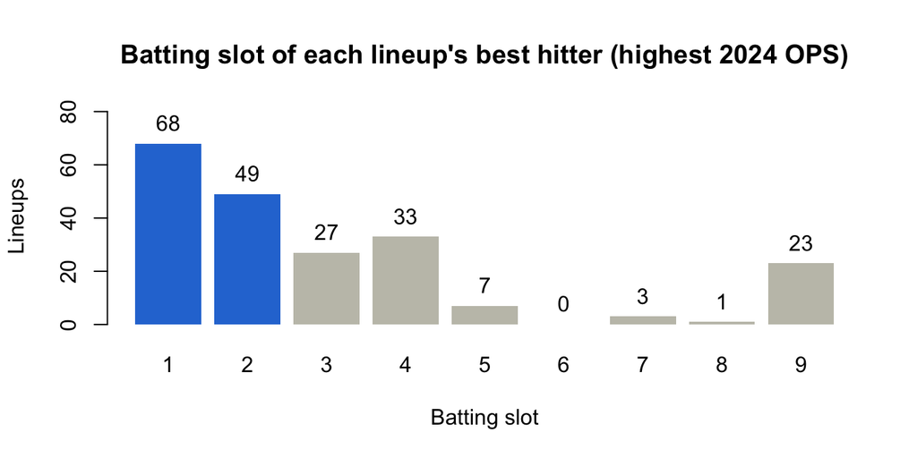

```r
best_slot <- sapply(lineup_list, function(d) d$slot[which.max(d$ops)])
best_counts <- table(factor(best_slot, levels = 1:9))
bars <- barplot(best_counts, col = ifelse(1:9 <= 2, "#2a78d6", "#c3c2b7"), border = NA,
                ylim = c(0, max(best_counts) * 1.2), xlab = "Batting slot", ylab = "Lineups",
                main = "Batting slot of each lineup's best hitter (highest 2024 OPS)")
text(bars, best_counts, labels = best_counts, pos = 3)
```

- The best hitter bats 1st or 2nd in 117 of 211 lineups and 3rd in only 27, mostly because Ohtani leads off and Devers, Tucker, and Contreras often bat 2nd.
- The slot-9 bar is Tyler Fitzgerald (Giants), whose high 2024 OPS came from only 341 PA.

**3. Many misses are tiny.**

```r
first_fail <- apply(checks, 1, function(ok) which(!ok)[1])
slot2_gap <- sapply(lineup_list[first_fail == 2], function(d) max(d$obp[2:9]) - d$obp[2])
knitr::kable(data.frame(lineups_failing_first_at_slot_2 = length(slot2_gap),
                        gap_010_or_less = sum(round(slot2_gap, 3) <= 0.010),
                        median_obp_gap = median(slot2_gap)))
```

| lineups_failing_first_at_slot_2 | gap_010_or_less | median_obp_gap |
| --- | --- | --- |
| 55 | 49 | 0.006 |

- An exact rule treats a few thousandths of OBP as decisive, which is well within the sampling noise of one season’s stats.

**4. Lineups change almost every game.**

```r
lineup_variation <- data.frame(team = sapply(lineup_list, function(d) d$team[1]),
                               order = sapply(lineup_list, function(d) paste(d$batter_id, collapse = ","))) %>%
  group_by(team) %>% summarise(games = n(), different_orders = n_distinct(order))
knitr::kable(lineup_variation)
```

| team | games | different_orders |
| --- | --- | --- |
| Angels | 13 | 10 |
| Cardinals | 56 | 35 |
| Cubs | 17 | 14 |
| Dodgers | 69 | 56 |
| Giants | 56 | 41 |

- Managers adjust for rest days, opposing pitchers, platoons, and current form, which a formula on last season’s stats cannot capture.

## 4.3 Conclusion

- Strategies A and B are recipes for building a lineup from nine hitters, not descriptions of how managers set lineups, so almost no real lineup matches them.
- Option 1: simulate both orders with the same nine hitters and compare expected runs, which matches the scope’s goal of testing whether rearranging the same hitters helps.
- Option 2: loosen the definition of the two groups, fixed before looking at runs. This changes the research question.
- The project team needs to choose before analysis continues.